# Background and Context

## Observations on Personal Loan vs variables not considered for the final model in Logistic regression

### Personal Loan vs Age

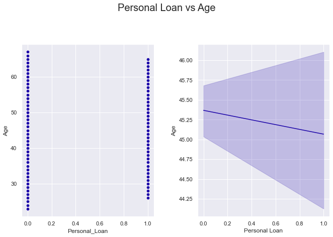

```python
fig, (ax1, ax2) = plt.subplots(1, 2, figsize=(10,7)) #creating subplots
ax1 = sns.scatterplot(x = 'Personal_Loan', ax = ax1,  y = 'Age', data = data) #scatterplot fo age vs price
ax2 = sns.lineplot(x = 'Personal_Loan', ax = ax2, y = 'Age', data = data) #lineplot of age vs price
plt.suptitle('Personal Loan vs Age',fontsize=20)
plt.xlabel('Personal Loan')
fig.tight_layout(pad=3.0)
plt.ylabel('Age')
```

Observation:

1. Age decreased for cleints that did take personal loan.
2. On average clients who are 45 and a half years took no laons
3. On average cleitns who just turned 45 were more likey to to take a loan

### Personal Loan vs Experience

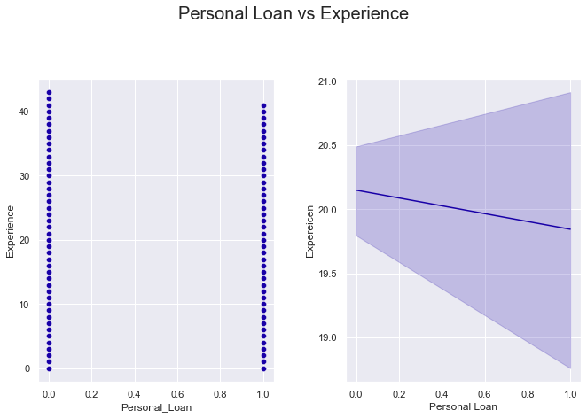

```python
fig, (ax1, ax2) = plt.subplots(1, 2, figsize=(10,7)) #creating subplots
ax1 = sns.scatterplot(x = 'Personal_Loan', ax = ax1,  y = 'Experience', data = data) #scatterplot fo age vs price
ax2 = sns.lineplot(x = 'Personal_Loan', ax = ax2, y = 'Experience', data = data) #lineplot of age vs price
plt.suptitle('Personal Loan vs Experience',fontsize=20)
plt.xlabel('Personal Loan')
fig.tight_layout(pad=3.0)
plt.ylabel('Expereicen')
```

Observation:

1. Clients who had lower experience took more personal loan
2. CLients who had higher experience took less personal loans

### Personal Loan vs Mortgage

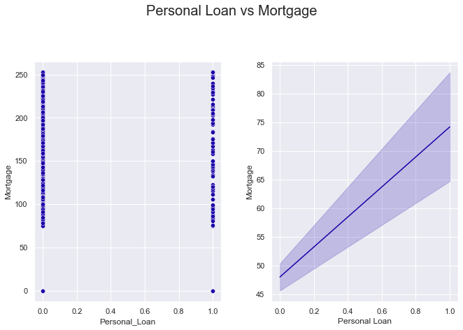

```python
fig, (ax1, ax2) = plt.subplots(1, 2, figsize=(10,7)) #creating subplots
ax1 = sns.scatterplot(x = 'Personal_Loan', ax = ax1,  y = 'Mortgage', data = data) #scatterplot fo age vs price
ax2 = sns.lineplot(x = 'Personal_Loan', ax = ax2, y = 'Mortgage', data = data) #lineplot of age vs price
plt.suptitle('Personal Loan vs Mortgage',fontsize=20)
plt.xlabel('Personal Loan')
fig.tight_layout(pad=3.0)
plt.ylabel('Mortgage')
```

Observation:

1. Clients who had lower Mortgage did not take personal loans
2. Clients who on average had 75 mortgage were more likely to take personal loans

### Data Preperation for Decision trees

```python
data = data.drop(['Major_city'],axis=1)
dummy_data = pd.get_dummies(data, columns=["Family", 'Education', 'Securities_Account', 'CD_Account', 'Online', 'CreditCard'],drop_first=True)
dummy_data.head()
```

| ID | Age | Experience | Income | CCAvg | Mortgage | Personal_Loan | Family_2 | Family_3 | Family_4 | Education_2 | Education_3 | Securities_Account_1 | CD_Account_1 | Online_1 | CreditCard_1 |
| --- | --- | --- | --- | --- | --- | --- | --- | --- | --- | --- | --- | --- | --- | --- | --- |
| 1 | 25 | 1 | 49.0 | 1.6 | 0.0 | 0 | 0 | 0 | 1 | 0 | 0 | 1 | 0 | 0 | 0 |
| 2 | 45 | 19 | 34.0 | 1.5 | 0.0 | 0 | 0 | 1 | 0 | 0 | 0 | 1 | 0 | 0 | 0 |
| 3 | 39 | 15 | 11.0 | 1.0 | 0.0 | 0 | 0 | 0 | 0 | 0 | 0 | 0 | 0 | 0 | 0 |
| 4 | 35 | 9 | 100.0 | 2.7 | 0.0 | 0 | 0 | 0 | 0 | 1 | 0 | 0 | 0 | 0 | 0 |
| 5 | 35 | 8 | 45.0 | 1.0 | 0.0 | 0 | 0 | 0 | 1 | 1 | 0 | 0 | 0 | 0 | 1 |

## Model Building - Approach

1. Data preparation
2. Partition the data into train and test set.
3. Built a CART model on the train data.
4. Tune the model and prune the tree, if required.
5. Test the data on test set.

```python
column_names = list(dummy_data.columns)
column_names.remove('Personal_Loan')                     # Keep only names of features by removing the name of target variable
feature_names = column_names
print(feature_names)
```

```
['Age', 'Experience', 'Income', 'CCAvg', 'Mortgage', 'Family_2', 'Family_3', 'Family_4', 'Education_2', 'Education_3', 'Securities_Account_1', 'CD_Account_1', 'Online_1', 'CreditCard_1']
```

## Split Data

```python
X = dummy_data.drop('Personal_Loan',axis=1)                                                 # Features
y = dummy_data['Personal_Loan'].astype('int64')                                             # Labels (Target Variable)
# converting target to integers - since some functions might not work with bool type
```

```python
# Splitting data into training and test set:
X_train, X_test, y_train, y_test =train_test_split(X, y, test_size=0.3, random_state=1)
print(X_train.shape, X_test.shape)
```

```
(3500, 14) (1500, 14)
```

## Build Decision Tree Model

- We will build our model using the DecisionTreeClassifier function. Using default 'gini' criteria to split.
- If the frequency of class A is 10% and the frequency of class B is 90%, then class B will become the dominant class and the decision tree will become biased toward the dominant classes.
- In this case, we can pass a dictionary {0:0.15,1:0.85} to the model to specify the weight of each class and the decision tree will give more weightage to class 1. |
- class_weight is a hyperparameter for the decision tree classifier.

```python
from sklearn import tree
from sklearn import metrics
from sklearn.tree import DecisionTreeClassifier
model = DecisionTreeClassifier(criterion='gini',class_weight={0:0.15,1:0.85},random_state=1)
```

```python
model.fit(X_train, y_train)
```

```
DecisionTreeClassifier(class_weight={0: 0.15, 1: 0.85}, random_state=1)
```

```python
def make_confusion_matrix(model,y_actual,labels=[1, 0]):
    '''
    model : classifier to predict values of X
    y_actual : ground truth

    '''
    y_predict = model.predict(X_test)
    cm=metrics.confusion_matrix( y_actual, y_predict, labels=[0, 1])
    df_cm = pd.DataFrame(cm, index = [i for i in ["Actual - No","Actual - Yes"]],
                  columns = [i for i in ['Predicted - No','Predicted - Yes']])
    group_counts = ["{0:0.0f}".format(value) for value in
                cm.flatten()]
    group_percentages = ["{0:.2%}".format(value) for value in
                         cm.flatten()/np.sum(cm)]
    labels = [f"{v1}\n{v2}" for v1, v2 in
              zip(group_counts,group_percentages)]
    labels = np.asarray(labels).reshape(2,2)
    plt.figure(figsize = (10,7))
    sns.heatmap(df_cm, annot=labels,fmt='')
    plt.ylabel('True label')
    plt.xlabel('Predicted label')
```

```python
y_train.value_counts(1)
```

```
0    0.905429
1    0.094571
Name: Personal_Loan, dtype: float64
```

We only have 9% of positive classes, so if our model marks each sample as negative, then also we'll get 90% accuracy, hence accuracy is not a good metric to evaluate here.

```python
##  Function to calculate recall score
def get_recall_score(model):
    '''
    model : classifier to predict values of X

    '''
    pred_train = model.predict(X_train)
    pred_test = model.predict(X_test)
    print("Recall on training set : ",metrics.recall_score(y_train,pred_train))
    print("Recall on test set : ",metrics.recall_score(y_test,pred_test))
```

```python
get_recall_score(model)
```

```
Recall on training set :  1.0
Recall on test set :  0.8926174496644296
```

There isn't a huge disparity in performance of model on training set and test set, which suggests that the model is good, but there is slight overfitting.

## Visualizing the Decision Tree

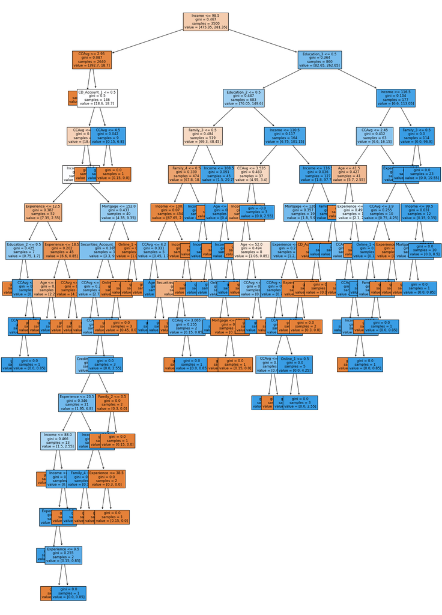

```python
plt.figure(figsize=(20,30))
out = tree.plot_tree(model,feature_names=feature_names,filled=True,fontsize=9,node_ids=False,class_names=None,)
#below code will add arrows to the decision tree split if they are missing
for o in out:
     arrow = o.arrow_patch
     if arrow is not None:
        arrow.set_edgecolor('black')
        arrow.set_linewidth(1)
plt.show()
```

```python
# Text report showing the rules of a decision tree -

print(tree.export_text(model,feature_names=feature_names,show_weights=True))
```

```
|--- Income <= 98.50
|   |--- CCAvg <= 2.95
|   |   |--- weights: [374.10, 0.00] class: 0
|   |--- CCAvg >  2.95
|   |   |--- CD_Account_1 <= 0.50
|   |   |   |--- CCAvg <= 3.95
|   |   |   |   |--- Income <= 81.50
|   |   |   |   |   |--- Experience <= 12.50
|   |   |   |   |   |   |--- Education_2 <= 0.50
|   |   |   |   |   |   |   |--- weights: [0.60, 0.00] class: 0
|   |   |   |   |   |   |--- Education_2 >  0.50
|   |   |   |   |   |   |   |--- CCAvg <= 3.50
|   |   |   |   |   |   |   |   |--- CCAvg <= 3.25
|   |   |   |   |   |   |   |   |   |--- weights: [0.00, 0.85] class: 1
|   |   |   |   |   |   |   |   |--- CCAvg >  3.25
|   |   |   |   |   |   |   |   |   |--- weights: [0.00, 0.85] class: 1
|   |   |   |   |   |   |   |--- CCAvg >  3.50
|   |   |   |   |   |   |   |   |--- weights: [0.15, 0.00] class: 0
|   |   |   |   |   |--- Experience >  12.50
|   |   |   |   |   |   |--- Experience <= 18.50
|   |   |   |   |   |   |   |--- Age <= 42.50
|   |   |   |   |   |   |   |   |--- weights: [2.25, 0.00] class: 0
|   |   |   |   |   |   |   |--- Age >  42.50
|   |   |   |   |   |   |   |   |--- weights: [0.00, 0.85] class: 1
|   |   |   |   |   |   |--- Experience >  18.50
|   |   |   |   |   |   |   |--- CCAvg <= 3.10
|   |   |   |   |   |   |   |   |--- weights: [1.05, 0.00] class: 0
|   |   |   |   |   |   |   |--- CCAvg >  3.10
|   |   |   |   |   |   |   |   |--- weights: [3.30, 0.00] class: 0
|   |   |   |   |--- Income >  81.50
|   |   |   |   |   |--- Mortgage <= 152.00
|   |   |   |   |   |   |--- Securities_Account_1 <= 0.50
|   |   |   |   |   |   |   |--- CCAvg <= 3.05
|   |   |   |   |   |   |   |   |--- weights: [0.45, 0.00] class: 0
|   |   |   |   |   |   |   |--- CCAvg >  3.05
|   |   |   |   |   |   |   |   |--- CCAvg <= 3.85
|   |   |   |   |   |   |   |   |   |--- CreditCard_1 <= 0.50
|   |   |   |   |   |   |   |   |   |   |--- Experience <= 20.50
|   |   |   |   |   |   |   |   |   |   |   |--- truncated branch of depth 5
|   |   |   |   |   |   |   |   |   |   |--- Experience >  20.50
```

[output cut: 153 more lines]

```
|   |   |   |   |   |   |--- Experience >  7.00
|   |   |   |   |   |   |   |--- weights: [0.45, 0.00] class: 0
|   |   |   |   |--- Experience >  16.50
|   |   |   |   |   |--- Income <= 99.50
|   |   |   |   |   |   |--- Mortgage <= 223.25
|   |   |   |   |   |   |   |--- weights: [0.15, 0.00] class: 0
|   |   |   |   |   |   |--- Mortgage >  223.25
|   |   |   |   |   |   |   |--- weights: [0.00, 0.85] class: 1
|   |   |   |   |   |--- Income >  99.50
|   |   |   |   |   |   |--- weights: [0.00, 8.50] class: 1
|   |   |--- Income >  116.50
|   |   |   |--- Family_3 <= 0.50
|   |   |   |   |--- weights: [0.00, 77.35] class: 1
|   |   |   |--- Family_3 >  0.50
|   |   |   |   |--- weights: [0.00, 19.55] class: 1
```

```python
# importance of features in the tree building ( The importance of a feature is computed as the
#(normalized) total reduction of the criterion brought by that feature. It is also known as the Gini importance )

print (pd.DataFrame(model.feature_importances_, columns = ["Imp"], index = X_train.columns).sort_values(by = 'Imp', ascending = False))
```

```
                               Imp
Income                5.978824e-01
CCAvg                 9.132013e-02
Education_2           9.029869e-02
Family_3              7.104576e-02
Family_4              6.900636e-02
Education_3           3.514783e-02
Experience            1.198951e-02
CD_Account_1          1.099955e-02
Age                   9.174049e-03
Mortgage              5.887150e-03
Securities_Account_1  4.716203e-03
Online_1              1.541163e-03
CreditCard_1          9.911646e-04
Family_2              4.993910e-18
```

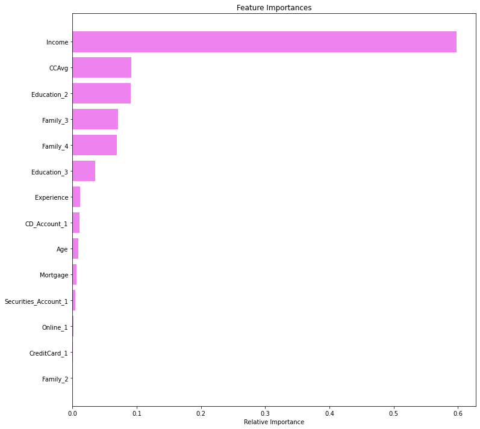

```python
importances = model.feature_importances_
indices = np.argsort(importances)

plt.figure(figsize=(12,12))
plt.title('Feature Importances')
plt.barh(range(len(indices)), importances[indices], color='violet', align='center')
plt.yticks(range(len(indices)), [feature_names[i] for i in indices])
plt.xlabel('Relative Importance')
plt.show()
```

The tree above is very complex and difficult to interpret.